# Colgate vs Crest

Andrea Jiménez Zúñiga

11/18/2020

Objetivo es predecir las 16 semanas del año 1963, para las dos cuotas de mercado, por lo que se dejará fuera de la muestra este periodo muestral. El análisis debe incluir para las dos series la estimación de un modelo ARIMA, la detección de atípicos/outliers y un modelo de interveción. Por último se debe realizar un modelo de función de tranferencia entre las dos cuotas.

# Libraries and functions

```r
library(tidyverse)
library(skimr)
library(modelr)
library(mgcv)
library(TSA)
library(ggplot2)
library(forecast)
library(zoo)
library(xts)
library(tsoutliers)
library(Hmisc)
```

## Data

```r
library(readxl)
cuotas_mercado <- read_excel("data.xlsx")
attach(cuotas_mercado)
```

Agrupo por semanas y transformo a formato fecha la columna date.

```r
cuotas_mercado$Date <- as.Date(paste(cuotas_mercado$Year, cuotas_mercado$Week,1,sep = "-"), "%Y-%U-%u")
cuotas_mercado <- dplyr::select(cuotas_mercado, -Year, -Week)
```

```r
cuotas_mercado <- as.data.frame(cuotas_mercado)
```

## Transformación de los datos.

Voy a transformar la base de datos a formato xts y zoo.

```r
xcuotas <- xts(cuotas_mercado[,-3], order.by = cuotas_mercado$Date) #Quito la columna date
xcuotas$Date = NULL

xcuotas1 <- xcuotas[,-1]  #PARA COLGATE
xcuotas2 <- xcuotas[,-2]  #PARA CREST
```

```r
zcuotas <- as.zoo(xcuotas)
zcuotas1 <- as.zoo(xcuotas1)
zcuotas2 <- as.zoo(xcuotas2)
```

Represento la evolución de ambas cuotas, para Colgate y para Crest, señalando la fecha del 1 de agosto de 1960, que fue cuando el Consejo de Terapéutica Dental de la American Dental Association (ADA) aprobó a Crest como una “ayuda importante en cualquier programa de higiene dental”.

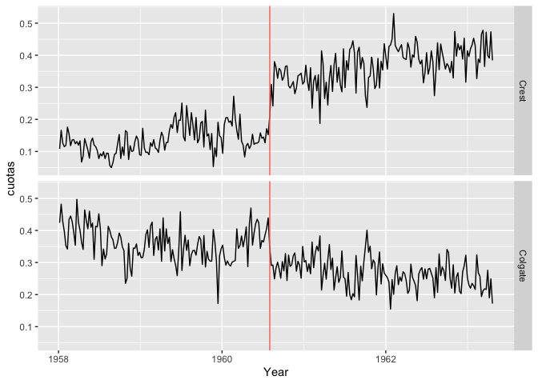

```r
autoplot(zcuotas) + ylab('cuotas') + xlab('Year') +
  geom_vline(aes(xintercept = as.Date('1960-08-01'), col = "red"), show.legend = F)
```

Se puede observar que Crest muestra una tendencia creciente y Colgate una tendencia decreciente. (a partir del 1 de agosto de 1960).

Plot de ambas:

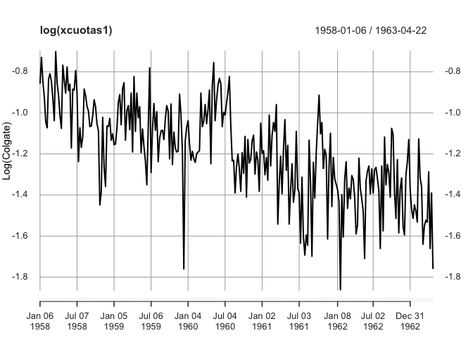

```r
plotColgate <- plot(log(xcuotas1), ylab= 'Log(Colgate)', xlab='Year')
plot(plotColgate)
```

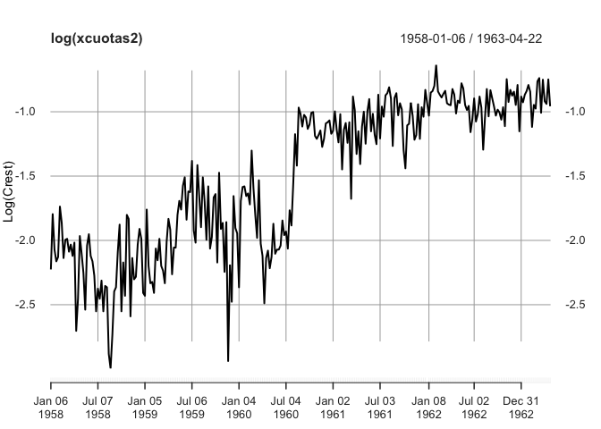

```r
plotCrest <- plot(log(xcuotas2), ylab= 'Log(Crest)', xlab='Year')
plot(plotCrest)
```

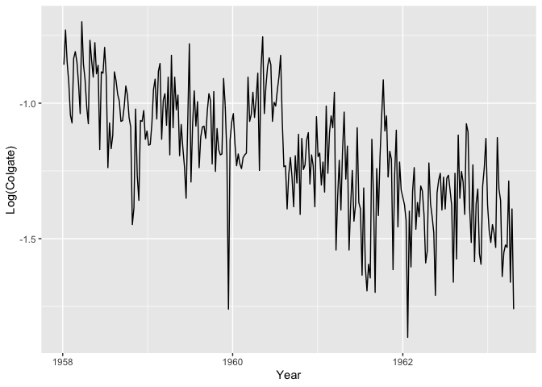

```r
autoplot(log(zcuotas1))+ylab('Log(Colgate)')+xlab('Year')
```

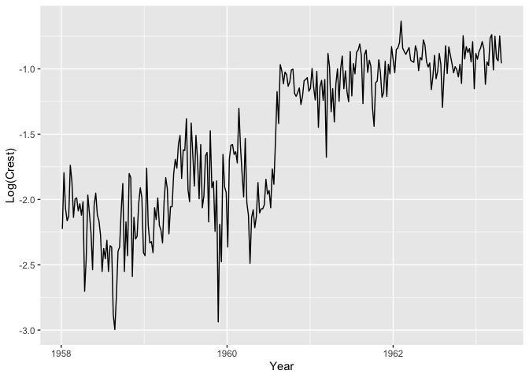

```r
autoplot(log(zcuotas2))+ylab('Log(Crest)')+xlab('Year')
```

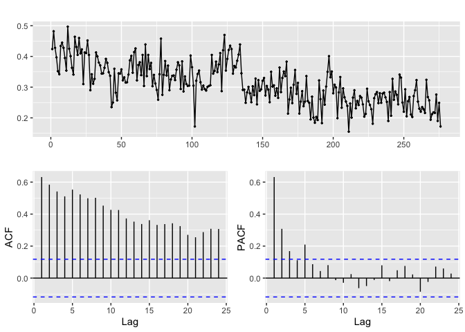

```r
ggtsdisplay(zcuotas1)
```

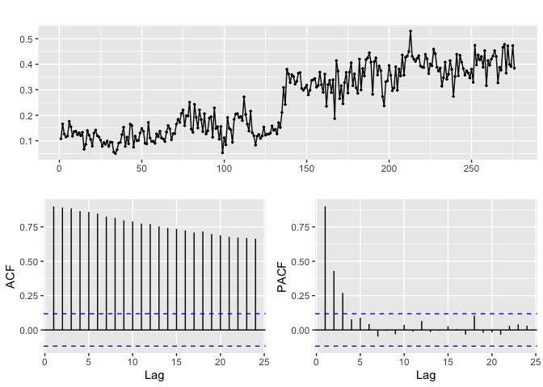

```r
ggtsdisplay(zcuotas2)
```

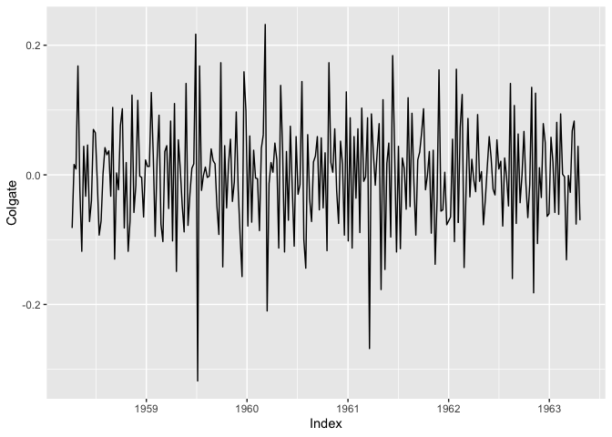

```r
autoplot(diff(diff(zcuotas1,12)))
```

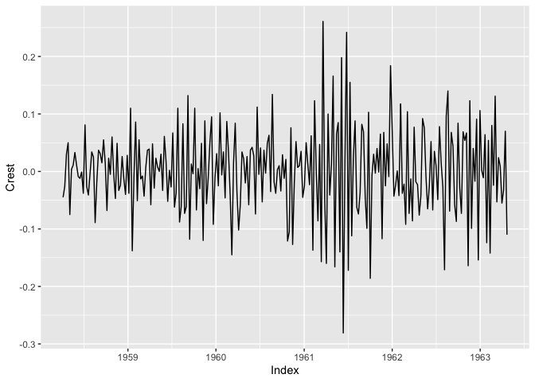

```r
autoplot(diff(diff(zcuotas2,12)))
```

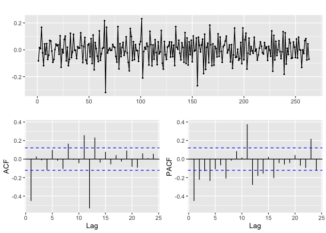

```r
ggtsdisplay(diff(diff(zcuotas1,12)))
```

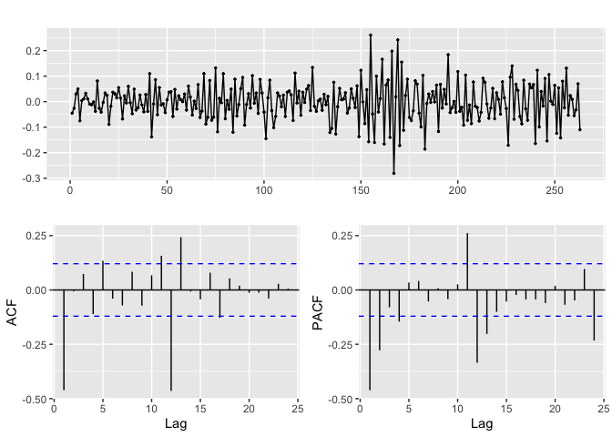

```r
ggtsdisplay(diff(diff(zcuotas2,12)))
```

# ARIMA

### Colgate:

A continuación selecciono el número de observaciones para comparar el forecast. Para ello omito los 16 últimos datos que corresponden a las semanas de 1963.

```r
cOmit = 16 #numero de observaciones para comparar el forecast

#El tamaño de los datos

nObs = length(zcuotas1)

# Subsample: Para la predicción
ocuotas1 <- window(zcuotas1, start = index(zcuotas1[1], end = index(zcuotas1[nObs-cOmit])))

# Out sample

pcuotas1 <- window(zcuotas1, start = index(zcuotas1[nObs-cOmit+1]), end = index(zcuotas1[nObs]))
pcuotas1
```

```
##            Colgate
## 1963-01-07   0.230
## 1963-01-14   0.220
## 1963-01-21   0.235
## 1963-01-28   0.228
## 1963-02-04   0.216
## 1963-02-11   0.324
## 1963-02-18   0.268
## 1963-02-25   0.257
## 1963-03-04   0.194
## 1963-03-11   0.212
## 1963-03-18   0.218
## 1963-03-25   0.216
## 1963-04-01   0.276
## 1963-04-08   0.190
## 1963-04-15   0.249
## 1963-04-22   0.172
```

#### ARIMA model automatic: fitting del modelo ARIMA.

```r
fitColgate = auto.arima(ocuotas1, lambda =0)
summary(fitColgate)
```

```
## Series: ocuotas1
## ARIMA(0,1,1)
## Box Cox transformation: lambda= 0
##
## Coefficients:
##           ma1
##       -0.7756
## s.e.   0.0451
##
## sigma^2 estimated as 0.02584:  log likelihood=112.47
## AIC=-220.95   AICc=-220.9   BIC=-213.71
##
## Training set error measures:
##                         ME      RMSE        MAE       MPE     MAPE      MASE
## Training set -0.0004814957 0.0474898 0.03758986 -2.422996 12.84065 0.1202123
##                    ACF1
## Training set 0.06139658
```

Se puede observar que el mejor modelo es el ARIMA(0,1,1) para Colgate.

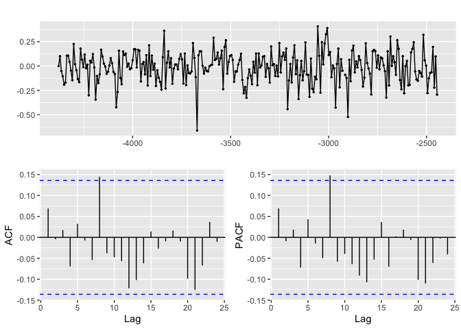

```r
ggtsdisplay(fitColgate$residuals)
```

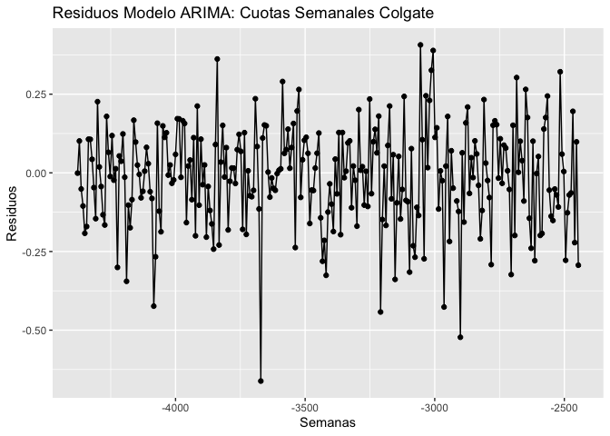

```r
gData=data.frame(Date=time(fitColgate$residuals), fitColgate$residuals, check.names=FALSE, row.names=NULL)
ggplot(gData, aes(x=ts(fitColgate$residuals))) +
  geom_point(aes(x=Date,y=fitColgate$residuals))+
  geom_line(aes(x=Date,y=fitColgate$residuals))+
  geom_hline(yintercept = 2*sd(fitColgate$residuals),color="red",linetype = 2)+
  geom_hline(yintercept = -2*sd(fitColgate$residuals),color="red",linetype = 2)+
  ylab("Residuos")+
  ggtitle("Residuos Modelo ARIMA: Cuotas Semanales Colgate")+
  xlab("Semanas")
```

Forecast

```r
fcuotas1.arima = forecast(fitColgate, h=16)
summary(fcuotas1.arima)
```

```
##
## Forecast method: ARIMA(0,1,1)
##
## Model Information:
## Series: ocuotas1
## ARIMA(0,1,1)
## Box Cox transformation: lambda= 0
##
## Coefficients:
##           ma1
##       -0.7756
## s.e.   0.0451
##
## sigma^2 estimated as 0.02584:  log likelihood=112.47
## AIC=-220.95   AICc=-220.9   BIC=-213.71
##
## Error measures:
##                         ME      RMSE        MAE       MPE     MAPE      MASE
## Training set -0.0004814957 0.0474898 0.03758986 -2.422996 12.84065 0.1202123
##                    ACF1
## Training set 0.06139658
##
## Forecasts:
##       Point Forecast     Lo 80     Hi 80     Lo 95     Hi 95
## -2439      0.2159815 0.1757747 0.2653851 0.1576156 0.2959606
## -2432      0.2159815 0.1748767 0.2667479 0.1563857 0.2982881
## -2425      0.2159815 0.1740044 0.2680852 0.1551943 0.3005781
## -2418      0.2159815 0.1731560 0.2693987 0.1540385 0.3028333
## -2411      0.2159815 0.1723300 0.2706899 0.1529162 0.3050561
## -2404      0.2159815 0.1715249 0.2719604 0.1518250 0.3072485
## -2397      0.2159815 0.1707396 0.2732114 0.1507631 0.3094126
## -2390      0.2159815 0.1699727 0.2744440 0.1497287 0.3115500
## -2383      0.2159815 0.1692234 0.2756593 0.1487204 0.3136624
## -2376      0.2159815 0.1684906 0.2768582 0.1477366 0.3157512
## -2369      0.2159815 0.1677734 0.2780416 0.1467760 0.3178176
## -2362      0.2159815 0.1670712 0.2792103 0.1458375 0.3198628
## -2355      0.2159815 0.1663831 0.2803649 0.1449199 0.3218881
## -2348      0.2159815 0.1657086 0.2815063 0.1440223 0.3238943
## -2341      0.2159815 0.1650468 0.2826349 0.1431436 0.3258824
## -2334      0.2159815 0.1643974 0.2837515 0.1422831 0.3278534
```

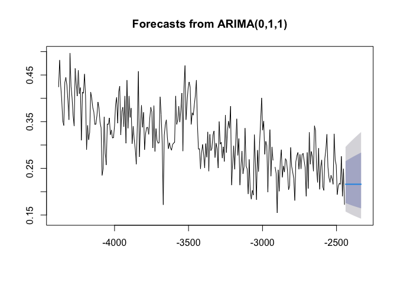

```r
plot(fcuotas1.arima)
```

```r
#Forecast out of the sample
cOmit=0

#Data Size
nObs=length(zcuotas1)

#sub_sample
ocuota1 <- window(zcuotas1,start=index(zcuotas1[1]),end=index(zcuotas1[nObs-cOmit]))
## ARIMA
fit2=auto.arima(ocuota1,lambda=0, d=1,D=0)
fventas.arima=forecast(fitColgate)

fventas.arima
```

```
##       Point Forecast     Lo 80     Hi 80     Lo 95     Hi 95
## -2439      0.2159815 0.1757747 0.2653851 0.1576156 0.2959606
## -2432      0.2159815 0.1748767 0.2667479 0.1563857 0.2982881
## -2425      0.2159815 0.1740044 0.2680852 0.1551943 0.3005781
## -2418      0.2159815 0.1731560 0.2693987 0.1540385 0.3028333
## -2411      0.2159815 0.1723300 0.2706899 0.1529162 0.3050561
## -2404      0.2159815 0.1715249 0.2719604 0.1518250 0.3072485
## -2397      0.2159815 0.1707396 0.2732114 0.1507631 0.3094126
## -2390      0.2159815 0.1699727 0.2744440 0.1497287 0.3115500
## -2383      0.2159815 0.1692234 0.2756593 0.1487204 0.3136624
## -2376      0.2159815 0.1684906 0.2768582 0.1477366 0.3157512
```

### Crest:

A continuación hago lo mismo que Colgate pero para Crest.

```r
cOmit = 16 #numero de observaciones para comparar el forecast

#El tamaño de los datos

nObs = length(zcuotas2)

# Subsample
ocuotas2 <- window(zcuotas2, start = index(zcuotas2[1], end = index(zcuotas2[nObs-cOmit])))

# Out sample

pcuotas2 <- window(zcuotas2, start = index(zcuotas2[nObs-cOmit+1]), end = index(zcuotas2[nObs]))
```

ARIMA model automatic

```r
fitCrest = auto.arima(ocuotas2, lambda =0)
summary(fitCrest)
```

```
## Series: ocuotas2
## ARIMA(3,1,0)
## Box Cox transformation: lambda= 0
##
## Coefficients:
##           ar1      ar2      ar3
##       -0.6188  -0.3730  -0.2216
## s.e.   0.0588   0.0659   0.0588
##
## sigma^2 estimated as 0.04962:  log likelihood=23.89
## AIC=-39.78   AICc=-39.63   BIC=-25.3
##
## Training set error measures:
##                       ME       RMSE        MAE       MPE     MAPE      MASE
## Training set 0.004777478 0.04690633 0.03635519 -1.521648 17.07422 0.1425491
##                    ACF1
## Training set -0.0879215
```

Se puede observar que el mejor modelo es el ARIMA(3,1,0) teniendo en cuenta el parámetro AIC.

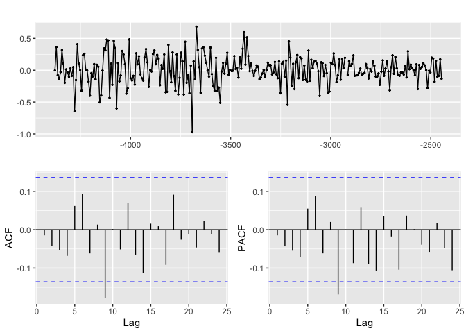

```r
ggtsdisplay(fitCrest$residuals)
```

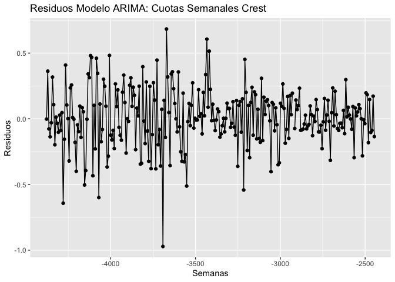

```r
gData=data.frame(Date=time(fitCrest$residuals), fitCrest$residuals, check.names=FALSE, row.names=NULL)
ggplot(gData, aes(x=fitCrest$residuals)) +
  geom_point(aes(x=Date,y=fitCrest$residuals))+
  geom_line(aes(x=Date,y=fitCrest$residuals))+
  geom_hline(yintercept = 2*sd(fitCrest$residuals),color="red",linetype = 2)+
  geom_hline(yintercept = -2*sd(fitCrest$residuals),color="red",linetype = 2)+
  ylab("Residuos")+
  ggtitle("Residuos Modelo ARIMA: Cuotas Semanales Crest")+
  xlab("Semanas")
```

Forecast

```r
fcuotas2.arima = forecast(fitCrest, h=16)
fcuotas2.arima
```

```
##       Point Forecast     Lo 80     Hi 80     Lo 95     Hi 95
## -2439      0.4087492 0.3072405 0.5437952 0.2641485 0.6325074
## -2432      0.4074914 0.3002172 0.5530972 0.2553862 0.6501889
## -2425      0.4177218 0.3017315 0.5783006 0.2540029 0.6869666
## -2418      0.4061751 0.2878925 0.5730549 0.2399379 0.6875871
## -2411      0.4097567 0.2814826 0.5964863 0.2307412 0.7276573
## -2404      0.4095637 0.2756291 0.6085803 0.2234990 0.7505287
## -2397      0.4108878 0.2711092 0.6227334 0.2175462 0.7760593
## -2390      0.4093431 0.2650250 0.6322489 0.2105435 0.7958534
## -2383      0.4098473 0.2602151 0.6455229 0.2045944 0.8210137
## -2376      0.4098178 0.2555985 0.6570877 0.1990768 0.8436475
## -2369      0.4099899 0.2513401 0.6687820 0.1939836 0.8665254
## -2362      0.4097826 0.2470659 0.6796639 0.1890119 0.8884192
## -2355      0.4098532 0.2431192 0.6909353 0.1843970 0.9109674
## -2348      0.4098487 0.2393354 0.7018434 0.1800271 0.9330596
## -2341      0.4098711 0.2357290 0.7126586 0.1758898 0.9551110
## -2334      0.4098433 0.2322430 0.7232575 0.1719336 0.9769557
```

Plot

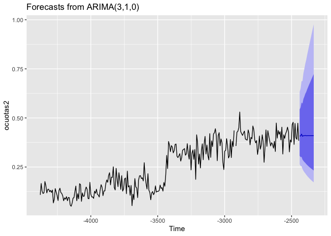

```r
autoplot(fcuotas2.arima)
```

```r
#Forecast out of the sample
cOmit=0

#Data Size
nObs=length(zcuotas2)

#sub_sample
ocuota2 <- window(zcuotas2,start=index(zcuotas2[1]),end=index(zcuotas2[nObs-cOmit]))
## ARIMA
fit2=auto.arima(ocuota2,lambda=0, d=1,D=0)
fventas.arima=forecast(fitCrest)

fventas.arima
```

```
##       Point Forecast     Lo 80     Hi 80     Lo 95     Hi 95
## -2439      0.4087492 0.3072405 0.5437952 0.2641485 0.6325074
## -2432      0.4074914 0.3002172 0.5530972 0.2553862 0.6501889
## -2425      0.4177218 0.3017315 0.5783006 0.2540029 0.6869666
## -2418      0.4061751 0.2878925 0.5730549 0.2399379 0.6875871
## -2411      0.4097567 0.2814826 0.5964863 0.2307412 0.7276573
## -2404      0.4095637 0.2756291 0.6085803 0.2234990 0.7505287
## -2397      0.4108878 0.2711092 0.6227334 0.2175462 0.7760593
## -2390      0.4093431 0.2650250 0.6322489 0.2105435 0.7958534
## -2383      0.4098473 0.2602151 0.6455229 0.2045944 0.8210137
## -2376      0.4098178 0.2555985 0.6570877 0.1990768 0.8436475
```

## Outliers:

Los outliers aditivos son incorporados como variables dummy en xreg. Los componentes de la función de transferencia son incorporados por el xtransf y transfer. Nuestra variable dummy es 1 de agosto de 1960, que se encuentra en la posición 135, esta va a tomar valor 1 y 0 en el resto de casos.

xtransf es una matriz cuyas columnas son las variables input.

```r
detectAO(fitColgate)
```

```
## [1] "No AO detected"
```

```r
detectAO(fitCrest)
```

```
## [1] "No AO detected"
```

```r
detectIO(fitColgate) # 99
```

[output not shown]

```r
detectIO(fitCrest) # 102
```

[output not shown]

### ARIMAX COLGATE

```r
arimax_colgate <-arimax(as.double(zcuotas1),order=c(0,1,1),
        xtransf=data.frame(I108=1*(seq(zcuotas1)>=135),
                           I108=1*(seq(zcuotas1)==135)),
        transfer=list(c(0,0),c(1,0)),
        io = c(99),
        method='ML')
arimax_colgate
```

```
##
## Call:
## arimax(x = as.double(zcuotas1), order = c(0, 1, 1), method = "ML", io = c(99),
##     xtransf = data.frame(I108 = 1 * (seq(zcuotas1) >= 135), I108 = 1 * (seq(zcuotas1) ==
##         135)), transfer = list(c(0, 0), c(1, 0)))
##
## Coefficients:
##           ma1   IO.99  I108-MA0  I108.1-AR1  I108.1-MA0
##       -0.8010  0.0816   -0.1159      0.1488      0.0631
## s.e.   0.0418  0.0462    0.0315      0.6644      0.0475
##
## sigma^2 estimated as 0.002129:  log likelihood = 455.22,  aic = -900.45
```

```r
arimax_colgate$coef
```

```
##         ma1       IO.99    I108-MA0  I108.1-AR1  I108.1-MA0
## -0.80100281  0.08156308 -0.11587671  0.14875470  0.06310815
```

### ARIMAX CREST

```r
arimax_crest <-arimax(as.double(zcuotas2),order=c(3,1,0),
        xtransf=data.frame(I108=1*(seq(zcuotas2)>=135),
                           I108=1*(seq(zcuotas2)==135)),
        xreg = data.frame(A60_2 = 1*(seq(zcuotas1) == 136)),
        transfer=list(c(0,0),c(1,0)),
        io = c(102),
        method='ML')
arimax_crest
```

```
##
## Call:
## arimax(x = as.double(zcuotas2), order = c(3, 1, 0), xreg = data.frame(A60_2 = 1 *
##     (seq(zcuotas1) == 136)), method = "ML", io = c(102), xtransf = data.frame(I108 = 1 *
##     (seq(zcuotas2) >= 135), I108 = 1 * (seq(zcuotas2) == 135)), transfer = list(c(0,
##     0), c(1, 0)))
##
## Coefficients:
##           ar1      ar2      ar3    A60_2  IO.102  I108-MA0  I108.1-AR1
##       -0.7128  -0.4524  -0.1583  -0.1147  0.0974    0.1805     -0.6190
## s.e.   0.0591   0.0677   0.0598   0.0574  0.0441    0.0422      0.1168
##       I108.1-MA0
##          -0.1344
## s.e.      0.0445
##
## sigma^2 estimated as 0.001917:  log likelihood = 469.81,  aic = -923.62
```

## Outliers

```r
detectAO(arimax_colgate)
```

```
## [1] "No AO detected"
```

```r
detectAO(arimax_crest)
```

```
## [1] "No AO detected"
```

```r
detectIO(arimax_colgate)
```

```
## [1] "No IO detected"
```

```r
detectIO(arimax_crest)
```

```
## [1] "No IO detected"
```

No hay outliers.

## Función de transferencia

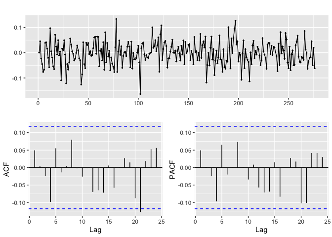

```r
ggtsdisplay(arimax_colgate$residuals)
```

```r
mod1 <- arimax(as.double(zcuotas1),
               order = c(0,1,1),
               include.mean = TRUE,
               xtransf=zcuotas2,
               transfer=list(c(0,0)),
               method = "ML")

mod1
```

```
##
## Call:
## arimax(x = as.double(zcuotas1), order = c(0, 1, 1), include.mean = TRUE, method = "ML",
##     xtransf = zcuotas2, transfer = list(c(0, 0)))
##
## Coefficients:
##           ma1  Crest-MA0
##       -0.8381    -0.4884
## s.e.   0.0346     0.0530
##
## sigma^2 estimated as 0.001751:  log likelihood = 481.99,  aic = -959.97
```

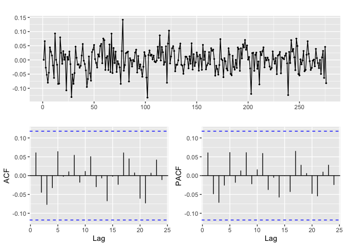

```r
ggtsdisplay(mod1$residuals)
```

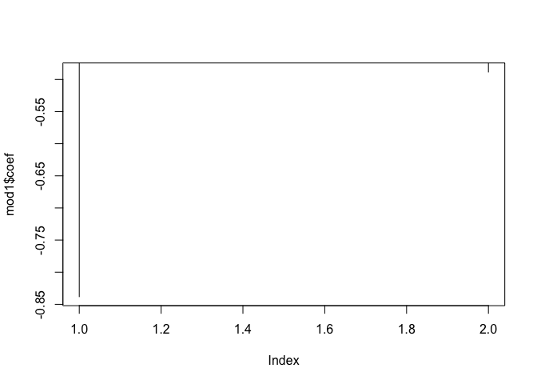

```r
plot(mod1$coef, type = "h")
```